# Risk Factor Analysis

## Outcome Variable

**Outcome Variable:** y_rate_haz

## Predictor Variables

**Intervention Variable:** safeh20

**Adjustment Set:**

unadjusted

## Stratifying Variables

The analysis was stratified on these variable(s):

- agecat
- studyid
- country

## Data Summary

| agecat | studyid | country | safeh20 | n_cell | n |
| --- | --- | --- | --- | --- | --- |
| 0-3 months | ki0047075b-MAL-ED | BANGLADESH | 1 | 0 | 236 |
| 0-3 months | ki0047075b-MAL-ED | BANGLADESH | 0 | 236 | 236 |
| 0-3 months | ki0047075b-MAL-ED | BRAZIL | 1 | 0 | 116 |
| 0-3 months | ki0047075b-MAL-ED | BRAZIL | 0 | 116 | 116 |
| 0-3 months | ki0047075b-MAL-ED | INDIA | 1 | 0 | 177 |
| 0-3 months | ki0047075b-MAL-ED | INDIA | 0 | 177 | 177 |
| 0-3 months | ki0047075b-MAL-ED | NEPAL | 1 | 1 | 153 |
| 0-3 months | ki0047075b-MAL-ED | NEPAL | 0 | 152 | 153 |
| 0-3 months | ki0047075b-MAL-ED | PERU | 1 | 11 | 243 |
| 0-3 months | ki0047075b-MAL-ED | PERU | 0 | 232 | 243 |
| 0-3 months | ki0047075b-MAL-ED | SOUTH AFRICA | 1 | 31 | 196 |
| 0-3 months | ki0047075b-MAL-ED | SOUTH AFRICA | 0 | 165 | 196 |
| 0-3 months | ki0047075b-MAL-ED | TANZANIA, UNITED REPUBLIC OF | 1 | 155 | 224 |
| 0-3 months | ki0047075b-MAL-ED | TANZANIA, UNITED REPUBLIC OF | 0 | 69 | 224 |
| 0-3 months | ki1017093-NIH-Birth | BANGLADESH | 1 | 564 | 566 |
| 0-3 months | ki1017093-NIH-Birth | BANGLADESH | 0 | 2 | 566 |
| 0-3 months | ki1017093b-PROVIDE | BANGLADESH | 1 | 13 | 13 |
| 0-3 months | ki1017093b-PROVIDE | BANGLADESH | 0 | 0 | 13 |
| 0-3 months | ki1017093c-NIH-Crypto | BANGLADESH | 1 | 721 | 721 |
| 0-3 months | ki1017093c-NIH-Crypto | BANGLADESH | 0 | 0 | 721 |
| 0-3 months | ki1114097-CONTENT | PERU | 1 | 5 | 6 |
| 0-3 months | ki1114097-CONTENT | PERU | 0 | 1 | 6 |
| 0-3 months | kiGH5241-JiVitA-3 | BANGLADESH | 1 | 9804 | 9817 |
| 0-3 months | kiGH5241-JiVitA-3 | BANGLADESH | 0 | 13 | 9817 |
| 0-3 months | kiGH5241-JiVitA-4 | BANGLADESH | 1 | 636 | 636 |
| 0-3 months | kiGH5241-JiVitA-4 | BANGLADESH | 0 | 0 | 636 |
| 3-6 months | ki0047075b-MAL-ED | BANGLADESH | 1 | 0 | 231 |
| 3-6 months | ki0047075b-MAL-ED | BANGLADESH | 0 | 231 | 231 |
| 3-6 months | ki0047075b-MAL-ED | BRAZIL | 1 | 0 | 141 |
| 3-6 months | ki0047075b-MAL-ED | BRAZIL | 0 | 141 | 141 |

[output cut: 182 more lines]

The following strata were considered:

- agecat: 0-3 months, studyid: ki0047075b-MAL-ED, country: BANGLADESH
- agecat: 0-3 months, studyid: ki0047075b-MAL-ED, country: BRAZIL
- agecat: 0-3 months, studyid: ki0047075b-MAL-ED, country: INDIA
- agecat: 0-3 months, studyid: ki0047075b-MAL-ED, country: NEPAL
- agecat: 0-3 months, studyid: ki0047075b-MAL-ED, country: PERU
- agecat: 0-3 months, studyid: ki0047075b-MAL-ED, country: SOUTH AFRICA
- agecat: 0-3 months, studyid: ki0047075b-MAL-ED, country: TANZANIA, UNITED REPUBLIC OF
- agecat: 0-3 months, studyid: ki1017093-NIH-Birth, country: BANGLADESH
- agecat: 0-3 months, studyid: ki1017093b-PROVIDE, country: BANGLADESH
- agecat: 0-3 months, studyid: ki1017093c-NIH-Crypto, country: BANGLADESH
- agecat: 0-3 months, studyid: ki1114097-CONTENT, country: PERU
- agecat: 0-3 months, studyid: kiGH5241-JiVitA-3, country: BANGLADESH
- agecat: 0-3 months, studyid: kiGH5241-JiVitA-4, country: BANGLADESH
- agecat: 12-15 months, studyid: ki0047075b-MAL-ED, country: BANGLADESH
- agecat: 12-15 months, studyid: ki0047075b-MAL-ED, country: BRAZIL
- agecat: 12-15 months, studyid: ki0047075b-MAL-ED, country: INDIA
- agecat: 12-15 months, studyid: ki0047075b-MAL-ED, country: NEPAL
- agecat: 12-15 months, studyid: ki0047075b-MAL-ED, country: PERU
- agecat: 12-15 months, studyid: ki0047075b-MAL-ED, country: SOUTH AFRICA
- agecat: 12-15 months, studyid: ki0047075b-MAL-ED, country: TANZANIA, UNITED REPUBLIC OF
- agecat: 12-15 months, studyid: ki1000304b-SAS-FoodSuppl, country: INDIA
- agecat: 12-15 months, studyid: ki1017093-NIH-Birth, country: BANGLADESH
- agecat: 12-15 months, studyid: ki1017093b-PROVIDE, country: BANGLADESH
- agecat: 12-15 months, studyid: ki1017093c-NIH-Crypto, country: BANGLADESH
- agecat: 12-15 months, studyid: ki1114097-CONTENT, country: PERU
- agecat: 12-15 months, studyid: ki1148112-LCNI-5, country: MALAWI
- agecat: 12-15 months, studyid: kiGH5241-JiVitA-4, country: BANGLADESH
- agecat: 15-18 months, studyid: ki0047075b-MAL-ED, country: BANGLADESH
- agecat: 15-18 months, studyid: ki0047075b-MAL-ED, country: BRAZIL
- agecat: 15-18 months, studyid: ki0047075b-MAL-ED, country: INDIA
- agecat: 15-18 months, studyid: ki0047075b-MAL-ED, country: NEPAL
- agecat: 15-18 months, studyid: ki0047075b-MAL-ED, country: PERU
- agecat: 15-18 months, studyid: ki0047075b-MAL-ED, country: SOUTH AFRICA
- agecat: 15-18 months, studyid: ki0047075b-MAL-ED, country: TANZANIA, UNITED REPUBLIC OF
- agecat: 15-18 months, studyid: ki1000304b-SAS-FoodSuppl, country: INDIA
- agecat: 15-18 months, studyid: ki1017093-NIH-Birth, country: BANGLADESH
- agecat: 15-18 months, studyid: ki1017093b-PROVIDE, country: BANGLADESH
- agecat: 15-18 months, studyid: ki1017093c-NIH-Crypto, country: BANGLADESH
- agecat: 15-18 months, studyid: ki1114097-CONTENT, country: PERU
- agecat: 15-18 months, studyid: ki1148112-LCNI-5, country: MALAWI
- agecat: 15-18 months, studyid: kiGH5241-JiVitA-4, country: BANGLADESH
- agecat: 18-21 months, studyid: ki0047075b-MAL-ED, country: BANGLADESH
- agecat: 18-21 months, studyid: ki0047075b-MAL-ED, country: BRAZIL
- agecat: 18-21 months, studyid: ki0047075b-MAL-ED, country: INDIA
- agecat: 18-21 months, studyid: ki0047075b-MAL-ED, country: NEPAL
- agecat: 18-21 months, studyid: ki0047075b-MAL-ED, country: PERU
- agecat: 18-21 months, studyid: ki0047075b-MAL-ED, country: SOUTH AFRICA
- agecat: 18-21 months, studyid: ki0047075b-MAL-ED, country: TANZANIA, UNITED REPUBLIC OF
- agecat: 18-21 months, studyid: ki1017093-NIH-Birth, country: BANGLADESH
- agecat: 18-21 months, studyid: ki1017093b-PROVIDE, country: BANGLADESH
- agecat: 18-21 months, studyid: ki1017093c-NIH-Crypto, country: BANGLADESH
- agecat: 18-21 months, studyid: ki1114097-CONTENT, country: PERU
- agecat: 18-21 months, studyid: ki1148112-LCNI-5, country: MALAWI
- agecat: 21-24 months, studyid: ki0047075b-MAL-ED, country: BANGLADESH
- agecat: 21-24 months, studyid: ki0047075b-MAL-ED, country: BRAZIL
- agecat: 21-24 months, studyid: ki0047075b-MAL-ED, country: INDIA
- agecat: 21-24 months, studyid: ki0047075b-MAL-ED, country: NEPAL
- agecat: 21-24 months, studyid: ki0047075b-MAL-ED, country: PERU
- agecat: 21-24 months, studyid: ki0047075b-MAL-ED, country: SOUTH AFRICA
- agecat: 21-24 months, studyid: ki0047075b-MAL-ED, country: TANZANIA, UNITED REPUBLIC OF
- agecat: 21-24 months, studyid: ki1017093-NIH-Birth, country: BANGLADESH
- agecat: 21-24 months, studyid: ki1017093b-PROVIDE, country: BANGLADESH
- agecat: 21-24 months, studyid: ki1017093c-NIH-Crypto, country: BANGLADESH
- agecat: 21-24 months, studyid: ki1114097-CONTENT, country: PERU
- agecat: 21-24 months, studyid: ki1148112-LCNI-5, country: MALAWI
- agecat: 3-6 months, studyid: ki0047075b-MAL-ED, country: BANGLADESH
- agecat: 3-6 months, studyid: ki0047075b-MAL-ED, country: BRAZIL
- agecat: 3-6 months, studyid: ki0047075b-MAL-ED, country: INDIA
- agecat: 3-6 months, studyid: ki0047075b-MAL-ED, country: NEPAL
- agecat: 3-6 months, studyid: ki0047075b-MAL-ED, country: PERU
- agecat: 3-6 months, studyid: ki0047075b-MAL-ED, country: SOUTH AFRICA
- agecat: 3-6 months, studyid: ki0047075b-MAL-ED, country: TANZANIA, UNITED REPUBLIC OF
- agecat: 3-6 months, studyid: ki1017093-NIH-Birth, country: BANGLADESH
- agecat: 3-6 months, studyid: ki1017093b-PROVIDE, country: BANGLADESH
- agecat: 3-6 months, studyid: ki1017093c-NIH-Crypto, country: BANGLADESH
- agecat: 3-6 months, studyid: ki1114097-CONTENT, country: PERU
- agecat: 3-6 months, studyid: kiGH5241-JiVitA-3, country: BANGLADESH
- agecat: 3-6 months, studyid: kiGH5241-JiVitA-4, country: BANGLADESH
- agecat: 6-9 months, studyid: ki0047075b-MAL-ED, country: BANGLADESH
- agecat: 6-9 months, studyid: ki0047075b-MAL-ED, country: BRAZIL
- agecat: 6-9 months, studyid: ki0047075b-MAL-ED, country: INDIA
- agecat: 6-9 months, studyid: ki0047075b-MAL-ED, country: NEPAL
- agecat: 6-9 months, studyid: ki0047075b-MAL-ED, country: PERU
- agecat: 6-9 months, studyid: ki0047075b-MAL-ED, country: SOUTH AFRICA
- agecat: 6-9 months, studyid: ki0047075b-MAL-ED, country: TANZANIA, UNITED REPUBLIC OF
- agecat: 6-9 months, studyid: ki1000304b-SAS-FoodSuppl, country: INDIA
- agecat: 6-9 months, studyid: ki1017093-NIH-Birth, country: BANGLADESH
- agecat: 6-9 months, studyid: ki1017093b-PROVIDE, country: BANGLADESH
- agecat: 6-9 months, studyid: ki1017093c-NIH-Crypto, country: BANGLADESH
- agecat: 6-9 months, studyid: ki1114097-CONTENT, country: PERU
- agecat: 6-9 months, studyid: ki1148112-LCNI-5, country: MALAWI
- agecat: 6-9 months, studyid: kiGH5241-JiVitA-4, country: BANGLADESH
- agecat: 9-12 months, studyid: ki0047075b-MAL-ED, country: BANGLADESH
- agecat: 9-12 months, studyid: ki0047075b-MAL-ED, country: BRAZIL
- agecat: 9-12 months, studyid: ki0047075b-MAL-ED, country: INDIA
- agecat: 9-12 months, studyid: ki0047075b-MAL-ED, country: NEPAL
- agecat: 9-12 months, studyid: ki0047075b-MAL-ED, country: PERU
- agecat: 9-12 months, studyid: ki0047075b-MAL-ED, country: SOUTH AFRICA
- agecat: 9-12 months, studyid: ki0047075b-MAL-ED, country: TANZANIA, UNITED REPUBLIC OF
- agecat: 9-12 months, studyid: ki1000304b-SAS-FoodSuppl, country: INDIA
- agecat: 9-12 months, studyid: ki1017093-NIH-Birth, country: BANGLADESH
- agecat: 9-12 months, studyid: ki1017093b-PROVIDE, country: BANGLADESH
- agecat: 9-12 months, studyid: ki1017093c-NIH-Crypto, country: BANGLADESH
- agecat: 9-12 months, studyid: ki1114097-CONTENT, country: PERU
- agecat: 9-12 months, studyid: ki1148112-LCNI-5, country: MALAWI
- agecat: 9-12 months, studyid: kiGH5241-JiVitA-4, country: BANGLADESH

### Dropped Strata

Some strata were dropped due to rare outcomes:

- agecat: 0-3 months, studyid: ki0047075b-MAL-ED, country: BANGLADESH
- agecat: 0-3 months, studyid: ki0047075b-MAL-ED, country: BRAZIL
- agecat: 0-3 months, studyid: ki0047075b-MAL-ED, country: INDIA
- agecat: 0-3 months, studyid: ki0047075b-MAL-ED, country: NEPAL
- agecat: 0-3 months, studyid: ki1017093-NIH-Birth, country: BANGLADESH
- agecat: 0-3 months, studyid: ki1017093b-PROVIDE, country: BANGLADESH
- agecat: 0-3 months, studyid: ki1017093c-NIH-Crypto, country: BANGLADESH
- agecat: 0-3 months, studyid: ki1114097-CONTENT, country: PERU
- agecat: 0-3 months, studyid: kiGH5241-JiVitA-4, country: BANGLADESH
- agecat: 3-6 months, studyid: ki0047075b-MAL-ED, country: BANGLADESH
- agecat: 3-6 months, studyid: ki0047075b-MAL-ED, country: BRAZIL
- agecat: 3-6 months, studyid: ki0047075b-MAL-ED, country: INDIA
- agecat: 3-6 months, studyid: ki0047075b-MAL-ED, country: NEPAL
- agecat: 3-6 months, studyid: ki1017093-NIH-Birth, country: BANGLADESH
- agecat: 3-6 months, studyid: ki1017093b-PROVIDE, country: BANGLADESH
- agecat: 3-6 months, studyid: ki1017093c-NIH-Crypto, country: BANGLADESH
- agecat: 3-6 months, studyid: ki1114097-CONTENT, country: PERU
- agecat: 3-6 months, studyid: kiGH5241-JiVitA-3, country: BANGLADESH
- agecat: 3-6 months, studyid: kiGH5241-JiVitA-4, country: BANGLADESH
- agecat: 6-9 months, studyid: ki0047075b-MAL-ED, country: BANGLADESH
- agecat: 6-9 months, studyid: ki0047075b-MAL-ED, country: BRAZIL
- agecat: 6-9 months, studyid: ki0047075b-MAL-ED, country: INDIA
- agecat: 6-9 months, studyid: ki0047075b-MAL-ED, country: NEPAL
- agecat: 6-9 months, studyid: ki1000304b-SAS-FoodSuppl, country: INDIA
- agecat: 6-9 months, studyid: ki1017093-NIH-Birth, country: BANGLADESH
- agecat: 6-9 months, studyid: ki1017093b-PROVIDE, country: BANGLADESH
- agecat: 6-9 months, studyid: ki1017093c-NIH-Crypto, country: BANGLADESH
- agecat: 6-9 months, studyid: ki1114097-CONTENT, country: PERU
- agecat: 6-9 months, studyid: kiGH5241-JiVitA-4, country: BANGLADESH
- agecat: 9-12 months, studyid: ki0047075b-MAL-ED, country: BANGLADESH
- agecat: 9-12 months, studyid: ki0047075b-MAL-ED, country: BRAZIL
- agecat: 9-12 months, studyid: ki0047075b-MAL-ED, country: INDIA
- agecat: 9-12 months, studyid: ki0047075b-MAL-ED, country: NEPAL
- agecat: 9-12 months, studyid: ki1000304b-SAS-FoodSuppl, country: INDIA
- agecat: 9-12 months, studyid: ki1017093-NIH-Birth, country: BANGLADESH
- agecat: 9-12 months, studyid: ki1017093b-PROVIDE, country: BANGLADESH
- agecat: 9-12 months, studyid: ki1017093c-NIH-Crypto, country: BANGLADESH
- agecat: 9-12 months, studyid: ki1114097-CONTENT, country: PERU
- agecat: 9-12 months, studyid: kiGH5241-JiVitA-4, country: BANGLADESH
- agecat: 12-15 months, studyid: ki0047075b-MAL-ED, country: BANGLADESH
- agecat: 12-15 months, studyid: ki0047075b-MAL-ED, country: BRAZIL
- agecat: 12-15 months, studyid: ki0047075b-MAL-ED, country: INDIA
- agecat: 12-15 months, studyid: ki0047075b-MAL-ED, country: NEPAL
- agecat: 12-15 months, studyid: ki1000304b-SAS-FoodSuppl, country: INDIA
- agecat: 12-15 months, studyid: ki1017093-NIH-Birth, country: BANGLADESH
- agecat: 12-15 months, studyid: ki1017093b-PROVIDE, country: BANGLADESH
- agecat: 12-15 months, studyid: ki1017093c-NIH-Crypto, country: BANGLADESH
- agecat: 12-15 months, studyid: ki1114097-CONTENT, country: PERU
- agecat: 12-15 months, studyid: kiGH5241-JiVitA-4, country: BANGLADESH
- agecat: 15-18 months, studyid: ki0047075b-MAL-ED, country: BANGLADESH
- agecat: 15-18 months, studyid: ki0047075b-MAL-ED, country: BRAZIL
- agecat: 15-18 months, studyid: ki0047075b-MAL-ED, country: INDIA
- agecat: 15-18 months, studyid: ki0047075b-MAL-ED, country: NEPAL
- agecat: 15-18 months, studyid: ki1000304b-SAS-FoodSuppl, country: INDIA
- agecat: 15-18 months, studyid: ki1017093-NIH-Birth, country: BANGLADESH
- agecat: 15-18 months, studyid: ki1017093b-PROVIDE, country: BANGLADESH
- agecat: 15-18 months, studyid: ki1017093c-NIH-Crypto, country: BANGLADESH
- agecat: 15-18 months, studyid: ki1114097-CONTENT, country: PERU
- agecat: 15-18 months, studyid: kiGH5241-JiVitA-4, country: BANGLADESH
- agecat: 18-21 months, studyid: ki0047075b-MAL-ED, country: BANGLADESH
- agecat: 18-21 months, studyid: ki0047075b-MAL-ED, country: BRAZIL
- agecat: 18-21 months, studyid: ki0047075b-MAL-ED, country: INDIA
- agecat: 18-21 months, studyid: ki0047075b-MAL-ED, country: NEPAL
- agecat: 18-21 months, studyid: ki1017093-NIH-Birth, country: BANGLADESH
- agecat: 18-21 months, studyid: ki1017093b-PROVIDE, country: BANGLADESH
- agecat: 18-21 months, studyid: ki1017093c-NIH-Crypto, country: BANGLADESH
- agecat: 18-21 months, studyid: ki1114097-CONTENT, country: PERU
- agecat: 21-24 months, studyid: ki0047075b-MAL-ED, country: BANGLADESH
- agecat: 21-24 months, studyid: ki0047075b-MAL-ED, country: BRAZIL
- agecat: 21-24 months, studyid: ki0047075b-MAL-ED, country: INDIA
- agecat: 21-24 months, studyid: ki0047075b-MAL-ED, country: NEPAL
- agecat: 21-24 months, studyid: ki1017093-NIH-Birth, country: BANGLADESH
- agecat: 21-24 months, studyid: ki1017093b-PROVIDE, country: BANGLADESH
- agecat: 21-24 months, studyid: ki1017093c-NIH-Crypto, country: BANGLADESH
- agecat: 21-24 months, studyid: ki1114097-CONTENT, country: PERU

## Methods Detail

We’re interested in the causal parameters $E[Y_a]$ for all values of $a \in \mathcal{A}$. These parameters represent the mean outcome if, possibly contrary to fact, we intervened to set all units to have $A=a$. Under the randomization and positivity assumptions, these are identified by the statistical parameters $\psi_a=E_W[E_{Y|A,W}(Y|A=a,W)]$. In addition, we’re interested in the mean of $Y$, $E[Y]$ under no intervention (the observed mean). We will estimate these parameters by using SuperLearner to fit the relevant likelihood factors – $E_{Y|A,W}(Y|A=a,W)$ and $p(A=a|W)$, and then updating our likelihood fit using a joint TMLE.

For unadjusted analyses ($W=\{\}$), initial likelihoods were estimated using Lrnr_glm to estimate the simple $E(Y|A)$ and Lrnr_mean to estimate $p(A)$. For adjusted analyses, a small library containing Lrnr_glmnet, Lrnr_xgboost, and Lrnr_mean was used.

Having estimated these parameters, we will then use the delta method to estimate relative risks and attributable risks relative to a prespecified baseline level of $A$.

# Results Detail

## Results Plots

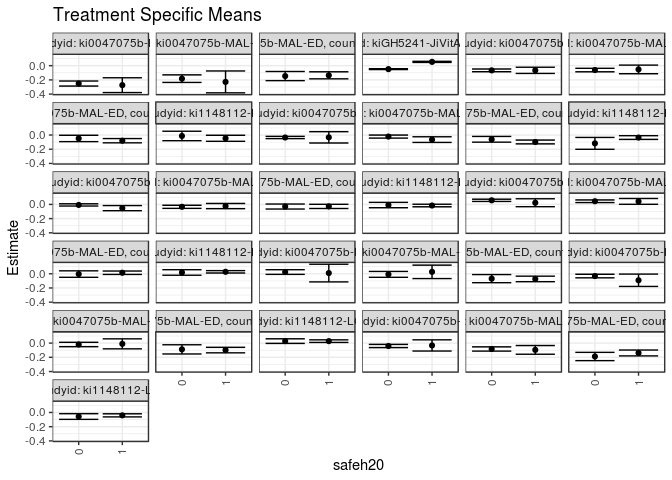

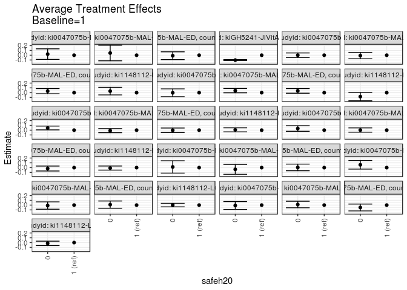

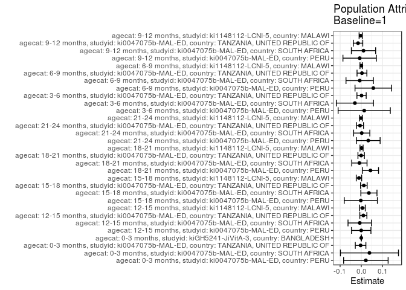

## Results Table

### Parameter: TSM

| agecat | studyid | country | intervention_level | baseline_level | estimate | ci_lower | ci_upper |
| --- | --- | --- | --- | --- | --- | --- | --- |
| 0-3 months | ki0047075b-MAL-ED | PERU | 1 | NA | -0.2741800 | -0.3783027 | -0.1700574 |
| 0-3 months | ki0047075b-MAL-ED | PERU | 0 | NA | -0.2515711 | -0.2871794 | -0.2159628 |
| 0-3 months | ki0047075b-MAL-ED | SOUTH AFRICA | 1 | NA | -0.2284712 | -0.3823085 | -0.0746340 |
| 0-3 months | ki0047075b-MAL-ED | SOUTH AFRICA | 0 | NA | -0.1827755 | -0.2360970 | -0.1294540 |
| 0-3 months | ki0047075b-MAL-ED | TANZANIA, UNITED REPUBLIC OF | 1 | NA | -0.1356788 | -0.1849851 | -0.0863726 |
| 0-3 months | ki0047075b-MAL-ED | TANZANIA, UNITED REPUBLIC OF | 0 | NA | -0.1464422 | -0.2108734 | -0.0820110 |
| 0-3 months | kiGH5241-JiVitA-3 | BANGLADESH | 1 | NA | 0.0534181 | 0.0457597 | 0.0610765 |
| 0-3 months | kiGH5241-JiVitA-3 | BANGLADESH | 0 | NA | -0.0487920 | -0.0550663 | -0.0425177 |
| 3-6 months | ki0047075b-MAL-ED | PERU | 1 | NA | 0.0098455 | -0.1145680 | 0.1342590 |
| 3-6 months | ki0047075b-MAL-ED | PERU | 0 | NA | 0.0242542 | -0.0088242 | 0.0573326 |
| 3-6 months | ki0047075b-MAL-ED | SOUTH AFRICA | 1 | NA | 0.0269050 | -0.0674921 | 0.1213021 |
| 3-6 months | ki0047075b-MAL-ED | SOUTH AFRICA | 0 | NA | -0.0086767 | -0.0500740 | 0.0327207 |
| 3-6 months | ki0047075b-MAL-ED | TANZANIA, UNITED REPUBLIC OF | 1 | NA | -0.0727068 | -0.1117404 | -0.0336732 |
| 3-6 months | ki0047075b-MAL-ED | TANZANIA, UNITED REPUBLIC OF | 0 | NA | -0.0687704 | -0.1260899 | -0.0114510 |
| 6-9 months | ki0047075b-MAL-ED | PERU | 1 | NA | -0.0916708 | -0.1782518 | -0.0050898 |
| 6-9 months | ki0047075b-MAL-ED | PERU | 0 | NA | -0.0324167 | -0.0577223 | -0.0071111 |
| 6-9 months | ki0047075b-MAL-ED | SOUTH AFRICA | 1 | NA | -0.0102498 | -0.0804345 | 0.0599350 |
| 6-9 months | ki0047075b-MAL-ED | SOUTH AFRICA | 0 | NA | -0.0191880 | -0.0500330 | 0.0116570 |
| 6-9 months | ki0047075b-MAL-ED | TANZANIA, UNITED REPUBLIC OF | 1 | NA | -0.0982239 | -0.1370553 | -0.0593924 |
| 6-9 months | ki0047075b-MAL-ED | TANZANIA, UNITED REPUBLIC OF | 0 | NA | -0.0881640 | -0.1527888 | -0.0235392 |
| 6-9 months | ki1148112-LCNI-5 | MALAWI | 1 | NA | 0.0278301 | 0.0098213 | 0.0458389 |
| 6-9 months | ki1148112-LCNI-5 | MALAWI | 0 | NA | 0.0284376 | -0.0039391 | 0.0608144 |
| 9-12 months | ki0047075b-MAL-ED | PERU | 1 | NA | -0.0326081 | -0.1116005 | 0.0463844 |
| 9-12 months | ki0047075b-MAL-ED | PERU | 0 | NA | -0.0406500 | -0.0632066 | -0.0180933 |
| 9-12 months | ki0047075b-MAL-ED | SOUTH AFRICA | 1 | NA | -0.0952228 | -0.1564356 | -0.0340100 |
| 9-12 months | ki0047075b-MAL-ED | SOUTH AFRICA | 0 | NA | -0.0827486 | -0.1126892 | -0.0528080 |
| 9-12 months | ki0047075b-MAL-ED | TANZANIA, UNITED REPUBLIC OF | 1 | NA | -0.1386388 | -0.1799468 | -0.0973308 |
| 9-12 months | ki0047075b-MAL-ED | TANZANIA, UNITED REPUBLIC OF | 0 | NA | -0.1882126 | -0.2463695 | -0.1300556 |
| 9-12 months | ki1148112-LCNI-5 | MALAWI | 1 | NA | -0.0405956 | -0.0624151 | -0.0187762 |
| 9-12 months | ki1148112-LCNI-5 | MALAWI | 0 | NA | -0.0568638 | -0.0969954 | -0.0167321 |
| 12-15 months | ki0047075b-MAL-ED | PERU | 1 | NA | -0.0657169 | -0.1092700 | -0.0221637 |
| 12-15 months | ki0047075b-MAL-ED | PERU | 0 | NA | -0.0660215 | -0.0851882 | -0.0468548 |
| 12-15 months | ki0047075b-MAL-ED | SOUTH AFRICA | 1 | NA | -0.0526575 | -0.1135558 | 0.0082408 |
| 12-15 months | ki0047075b-MAL-ED | SOUTH AFRICA | 0 | NA | -0.0614240 | -0.0861065 | -0.0367415 |
| 12-15 months | ki0047075b-MAL-ED | TANZANIA, UNITED REPUBLIC OF | 1 | NA | -0.0799073 | -0.1100774 | -0.0497372 |
| 12-15 months | ki0047075b-MAL-ED | TANZANIA, UNITED REPUBLIC OF | 0 | NA | -0.0481057 | -0.0930234 | -0.0031880 |
| 12-15 months | ki1148112-LCNI-5 | MALAWI | 1 | NA | -0.0457654 | -0.0881354 | -0.0033954 |
| 12-15 months | ki1148112-LCNI-5 | MALAWI | 0 | NA | -0.0133177 | -0.0800327 | 0.0533972 |
| 15-18 months | ki0047075b-MAL-ED | PERU | 1 | NA | -0.0323292 | -0.1121274 | 0.0474690 |
| 15-18 months | ki0047075b-MAL-ED | PERU | 0 | NA | -0.0347368 | -0.0509458 | -0.0185277 |
| 15-18 months | ki0047075b-MAL-ED | SOUTH AFRICA | 1 | NA | -0.0643710 | -0.1041675 | -0.0245745 |
| 15-18 months | ki0047075b-MAL-ED | SOUTH AFRICA | 0 | NA | -0.0217737 | -0.0430037 | -0.0005436 |
| 15-18 months | ki0047075b-MAL-ED | TANZANIA, UNITED REPUBLIC OF | 1 | NA | -0.0977238 | -0.1244902 | -0.0709575 |
| 15-18 months | ki0047075b-MAL-ED | TANZANIA, UNITED REPUBLIC OF | 0 | NA | -0.0603133 | -0.1007081 | -0.0199185 |
| 15-18 months | ki1148112-LCNI-5 | MALAWI | 1 | NA | -0.0353804 | -0.0615797 | -0.0091812 |
| 15-18 months | ki1148112-LCNI-5 | MALAWI | 0 | NA | -0.1173555 | -0.2008952 | -0.0338158 |
| 18-21 months | ki0047075b-MAL-ED | PERU | 1 | NA | -0.0527482 | -0.0889320 | -0.0165645 |
| 18-21 months | ki0047075b-MAL-ED | PERU | 0 | NA | -0.0074914 | -0.0233551 | 0.0083722 |
| 18-21 months | ki0047075b-MAL-ED | SOUTH AFRICA | 1 | NA | -0.0235376 | -0.0600223 | 0.0129470 |
| 18-21 months | ki0047075b-MAL-ED | SOUTH AFRICA | 0 | NA | -0.0340734 | -0.0557757 | -0.0123710 |
| 18-21 months | ki0047075b-MAL-ED | TANZANIA, UNITED REPUBLIC OF | 1 | NA | -0.0282824 | -0.0578553 | 0.0012904 |
| 18-21 months | ki0047075b-MAL-ED | TANZANIA, UNITED REPUBLIC OF | 0 | NA | -0.0301784 | -0.0654663 | 0.0051095 |
| 18-21 months | ki1148112-LCNI-5 | MALAWI | 1 | NA | -0.0158941 | -0.0338633 | 0.0020750 |
| 18-21 months | ki1148112-LCNI-5 | MALAWI | 0 | NA | -0.0092616 | -0.0471423 | 0.0286191 |
| 21-24 months | ki0047075b-MAL-ED | PERU | 1 | NA | 0.0232134 | -0.0327597 | 0.0791864 |
| 21-24 months | ki0047075b-MAL-ED | PERU | 0 | NA | 0.0574631 | 0.0416924 | 0.0732338 |
| 21-24 months | ki0047075b-MAL-ED | SOUTH AFRICA | 1 | NA | 0.0420213 | 0.0013276 | 0.0827151 |
| 21-24 months | ki0047075b-MAL-ED | SOUTH AFRICA | 0 | NA | 0.0444395 | 0.0260031 | 0.0628760 |
| 21-24 months | ki0047075b-MAL-ED | TANZANIA, UNITED REPUBLIC OF | 1 | NA | 0.0142802 | -0.0095364 | 0.0380968 |
| 21-24 months | ki0047075b-MAL-ED | TANZANIA, UNITED REPUBLIC OF | 0 | NA | -0.0046025 | -0.0499998 | 0.0407947 |
| 21-24 months | ki1148112-LCNI-5 | MALAWI | 1 | NA | 0.0272298 | 0.0105488 | 0.0439109 |
| 21-24 months | ki1148112-LCNI-5 | MALAWI | 0 | NA | 0.0183132 | -0.0206414 | 0.0572678 |

### Parameter: E(Y)

| agecat | studyid | country | intervention_level | baseline_level | estimate | ci_lower | ci_upper |
| --- | --- | --- | --- | --- | --- | --- | --- |
| 0-3 months | ki0047075b-MAL-ED | PERU | NA | NA | -0.2525945 | -0.2869213 | -0.2182678 |
| 0-3 months | ki0047075b-MAL-ED | SOUTH AFRICA | NA | NA | -0.1900029 | -0.2411148 | -0.1388910 |
| 0-3 months | ki0047075b-MAL-ED | TANZANIA, UNITED REPUBLIC OF | NA | NA | -0.1389943 | -0.1784707 | -0.0995180 |
| 0-3 months | kiGH5241-JiVitA-3 | BANGLADESH | NA | NA | 0.0532828 | 0.0458161 | 0.0607494 |
| 3-6 months | ki0047075b-MAL-ED | PERU | NA | NA | 0.0236350 | -0.0084722 | 0.0557423 |
| 3-6 months | ki0047075b-MAL-ED | SOUTH AFRICA | NA | NA | -0.0033394 | -0.0413034 | 0.0346246 |
| 3-6 months | ki0047075b-MAL-ED | TANZANIA, UNITED REPUBLIC OF | NA | NA | -0.0714664 | -0.1037306 | -0.0392021 |
| 6-9 months | ki0047075b-MAL-ED | PERU | NA | NA | -0.0349381 | -0.0594933 | -0.0103830 |
| 6-9 months | ki0047075b-MAL-ED | SOUTH AFRICA | NA | NA | -0.0177890 | -0.0460334 | 0.0104554 |
| 6-9 months | ki0047075b-MAL-ED | TANZANIA, UNITED REPUBLIC OF | NA | NA | -0.0951251 | -0.1285712 | -0.0616789 |
| 6-9 months | ki1148112-LCNI-5 | MALAWI | NA | NA | 0.0279334 | 0.0120046 | 0.0438622 |
| 9-12 months | ki0047075b-MAL-ED | PERU | NA | NA | -0.0403297 | -0.0622163 | -0.0184431 |
| 9-12 months | ki0047075b-MAL-ED | SOUTH AFRICA | NA | NA | -0.0847380 | -0.1117373 | -0.0577388 |
| 9-12 months | ki0047075b-MAL-ED | TANZANIA, UNITED REPUBLIC OF | NA | NA | -0.1539778 | -0.1878402 | -0.1201153 |
| 9-12 months | ki1148112-LCNI-5 | MALAWI | NA | NA | -0.0433141 | -0.0626948 | -0.0239333 |
| 12-15 months | ki0047075b-MAL-ED | PERU | NA | NA | -0.0660102 | -0.0845347 | -0.0474856 |
| 12-15 months | ki0047075b-MAL-ED | SOUTH AFRICA | NA | NA | -0.0600337 | -0.0829414 | -0.0371260 |
| 12-15 months | ki0047075b-MAL-ED | TANZANIA, UNITED REPUBLIC OF | NA | NA | -0.0701548 | -0.0952743 | -0.0450353 |
| 12-15 months | ki1148112-LCNI-5 | MALAWI | NA | NA | -0.0403575 | -0.0774359 | -0.0032790 |
| 15-18 months | ki0047075b-MAL-ED | PERU | NA | NA | -0.0346428 | -0.0505277 | -0.0187579 |
| 15-18 months | ki0047075b-MAL-ED | SOUTH AFRICA | NA | NA | -0.0284295 | -0.0474993 | -0.0093597 |
| 15-18 months | ki0047075b-MAL-ED | TANZANIA, UNITED REPUBLIC OF | NA | NA | -0.0857732 | -0.1082180 | -0.0633284 |
| 15-18 months | ki1148112-LCNI-5 | MALAWI | NA | NA | -0.0464023 | -0.0722064 | -0.0205982 |
| 18-21 months | ki0047075b-MAL-ED | PERU | NA | NA | -0.0093386 | -0.0246779 | 0.0060006 |
| 18-21 months | ki0047075b-MAL-ED | SOUTH AFRICA | NA | NA | -0.0324839 | -0.0517228 | -0.0132451 |
| 18-21 months | ki0047075b-MAL-ED | TANZANIA, UNITED REPUBLIC OF | NA | NA | -0.0289082 | -0.0518906 | -0.0059258 |
| 18-21 months | ki1148112-LCNI-5 | MALAWI | NA | NA | -0.0147327 | -0.0309734 | 0.0015080 |
| 21-24 months | ki0047075b-MAL-ED | PERU | NA | NA | 0.0561458 | 0.0407996 | 0.0714920 |
| 21-24 months | ki0047075b-MAL-ED | SOUTH AFRICA | NA | NA | 0.0440882 | 0.0272574 | 0.0609190 |
| 21-24 months | ki0047075b-MAL-ED | TANZANIA, UNITED REPUBLIC OF | NA | NA | 0.0082340 | -0.0135584 | 0.0300264 |
| 21-24 months | ki1148112-LCNI-5 | MALAWI | NA | NA | 0.0258428 | 0.0105053 | 0.0411803 |

### Parameter: ATE

| agecat | studyid | country | intervention_level | baseline_level | estimate | ci_lower | ci_upper |
| --- | --- | --- | --- | --- | --- | --- | --- |
| 0-3 months | ki0047075b-MAL-ED | PERU | 1 | 1 | 0.0000000 | 0.0000000 | 0.0000000 |
| 0-3 months | ki0047075b-MAL-ED | PERU | 0 | 1 | 0.0226089 | -0.0874342 | 0.1326520 |
| 0-3 months | ki0047075b-MAL-ED | SOUTH AFRICA | 1 | 1 | 0.0000000 | 0.0000000 | 0.0000000 |
| 0-3 months | ki0047075b-MAL-ED | SOUTH AFRICA | 0 | 1 | 0.0456957 | -0.1171204 | 0.2085118 |
| 0-3 months | ki0047075b-MAL-ED | TANZANIA, UNITED REPUBLIC OF | 1 | 1 | 0.0000000 | 0.0000000 | 0.0000000 |
| 0-3 months | ki0047075b-MAL-ED | TANZANIA, UNITED REPUBLIC OF | 0 | 1 | -0.0107634 | -0.0918959 | 0.0703692 |
| 0-3 months | kiGH5241-JiVitA-3 | BANGLADESH | 1 | 1 | 0.0000000 | 0.0000000 | 0.0000000 |
| 0-3 months | kiGH5241-JiVitA-3 | BANGLADESH | 0 | 1 | -0.1022101 | -0.1120354 | -0.0923847 |
| 3-6 months | ki0047075b-MAL-ED | PERU | 1 | 1 | 0.0000000 | 0.0000000 | 0.0000000 |
| 3-6 months | ki0047075b-MAL-ED | PERU | 0 | 1 | 0.0144087 | -0.1143271 | 0.1431445 |
| 3-6 months | ki0047075b-MAL-ED | SOUTH AFRICA | 1 | 1 | 0.0000000 | 0.0000000 | 0.0000000 |
| 3-6 months | ki0047075b-MAL-ED | SOUTH AFRICA | 0 | 1 | -0.0355817 | -0.1386571 | 0.0674938 |
| 3-6 months | ki0047075b-MAL-ED | TANZANIA, UNITED REPUBLIC OF | 1 | 1 | 0.0000000 | 0.0000000 | 0.0000000 |
| 3-6 months | ki0047075b-MAL-ED | TANZANIA, UNITED REPUBLIC OF | 0 | 1 | 0.0039364 | -0.0654116 | 0.0732844 |
| 6-9 months | ki0047075b-MAL-ED | PERU | 1 | 1 | 0.0000000 | 0.0000000 | 0.0000000 |
| 6-9 months | ki0047075b-MAL-ED | PERU | 0 | 1 | 0.0592541 | -0.0309493 | 0.1494575 |
| 6-9 months | ki0047075b-MAL-ED | SOUTH AFRICA | 1 | 1 | 0.0000000 | 0.0000000 | 0.0000000 |
| 6-9 months | ki0047075b-MAL-ED | SOUTH AFRICA | 0 | 1 | -0.0089382 | -0.0856019 | 0.0677254 |
| 6-9 months | ki0047075b-MAL-ED | TANZANIA, UNITED REPUBLIC OF | 1 | 1 | 0.0000000 | 0.0000000 | 0.0000000 |
| 6-9 months | ki0047075b-MAL-ED | TANZANIA, UNITED REPUBLIC OF | 0 | 1 | 0.0100599 | -0.0653341 | 0.0854538 |
| 6-9 months | ki1148112-LCNI-5 | MALAWI | 1 | 1 | 0.0000000 | 0.0000000 | 0.0000000 |
| 6-9 months | ki1148112-LCNI-5 | MALAWI | 0 | 1 | 0.0006075 | -0.0364407 | 0.0376557 |
| 9-12 months | ki0047075b-MAL-ED | PERU | 1 | 1 | 0.0000000 | 0.0000000 | 0.0000000 |
| 9-12 months | ki0047075b-MAL-ED | PERU | 0 | 1 | -0.0080419 | -0.0901918 | 0.0741080 |
| 9-12 months | ki0047075b-MAL-ED | SOUTH AFRICA | 1 | 1 | 0.0000000 | 0.0000000 | 0.0000000 |
| 9-12 months | ki0047075b-MAL-ED | SOUTH AFRICA | 0 | 1 | 0.0124742 | -0.0556686 | 0.0806170 |
| 9-12 months | ki0047075b-MAL-ED | TANZANIA, UNITED REPUBLIC OF | 1 | 1 | 0.0000000 | 0.0000000 | 0.0000000 |
| 9-12 months | ki0047075b-MAL-ED | TANZANIA, UNITED REPUBLIC OF | 0 | 1 | -0.0495737 | -0.1209080 | 0.0217605 |
| 9-12 months | ki1148112-LCNI-5 | MALAWI | 1 | 1 | 0.0000000 | 0.0000000 | 0.0000000 |
| 9-12 months | ki1148112-LCNI-5 | MALAWI | 0 | 1 | -0.0162681 | -0.0619479 | 0.0294116 |
| 12-15 months | ki0047075b-MAL-ED | PERU | 1 | 1 | 0.0000000 | 0.0000000 | 0.0000000 |
| 12-15 months | ki0047075b-MAL-ED | PERU | 0 | 1 | -0.0003046 | -0.0478886 | 0.0472794 |
| 12-15 months | ki0047075b-MAL-ED | SOUTH AFRICA | 1 | 1 | 0.0000000 | 0.0000000 | 0.0000000 |
| 12-15 months | ki0047075b-MAL-ED | SOUTH AFRICA | 0 | 1 | -0.0087665 | -0.0744766 | 0.0569437 |
| 12-15 months | ki0047075b-MAL-ED | TANZANIA, UNITED REPUBLIC OF | 1 | 1 | 0.0000000 | 0.0000000 | 0.0000000 |
| 12-15 months | ki0047075b-MAL-ED | TANZANIA, UNITED REPUBLIC OF | 0 | 1 | 0.0318016 | -0.0223079 | 0.0859111 |
| 12-15 months | ki1148112-LCNI-5 | MALAWI | 1 | 1 | 0.0000000 | 0.0000000 | 0.0000000 |
| 12-15 months | ki1148112-LCNI-5 | MALAWI | 0 | 1 | 0.0324477 | -0.0465846 | 0.1114800 |
| 15-18 months | ki0047075b-MAL-ED | PERU | 1 | 1 | 0.0000000 | 0.0000000 | 0.0000000 |
| 15-18 months | ki0047075b-MAL-ED | PERU | 0 | 1 | -0.0024076 | -0.0838354 | 0.0790202 |
| 15-18 months | ki0047075b-MAL-ED | SOUTH AFRICA | 1 | 1 | 0.0000000 | 0.0000000 | 0.0000000 |
| 15-18 months | ki0047075b-MAL-ED | SOUTH AFRICA | 0 | 1 | 0.0425973 | -0.0025079 | 0.0877025 |
| 15-18 months | ki0047075b-MAL-ED | TANZANIA, UNITED REPUBLIC OF | 1 | 1 | 0.0000000 | 0.0000000 | 0.0000000 |
| 15-18 months | ki0047075b-MAL-ED | TANZANIA, UNITED REPUBLIC OF | 0 | 1 | 0.0374105 | -0.0110475 | 0.0858685 |
| 15-18 months | ki1148112-LCNI-5 | MALAWI | 1 | 1 | 0.0000000 | 0.0000000 | 0.0000000 |
| 15-18 months | ki1148112-LCNI-5 | MALAWI | 0 | 1 | -0.0819751 | -0.1695267 | 0.0055766 |
| 18-21 months | ki0047075b-MAL-ED | PERU | 1 | 1 | 0.0000000 | 0.0000000 | 0.0000000 |
| 18-21 months | ki0047075b-MAL-ED | PERU | 0 | 1 | 0.0452568 | 0.0057484 | 0.0847653 |
| 18-21 months | ki0047075b-MAL-ED | SOUTH AFRICA | 1 | 1 | 0.0000000 | 0.0000000 | 0.0000000 |
| 18-21 months | ki0047075b-MAL-ED | SOUTH AFRICA | 0 | 1 | -0.0105357 | -0.0529871 | 0.0319157 |
| 18-21 months | ki0047075b-MAL-ED | TANZANIA, UNITED REPUBLIC OF | 1 | 1 | 0.0000000 | 0.0000000 | 0.0000000 |
| 18-21 months | ki0047075b-MAL-ED | TANZANIA, UNITED REPUBLIC OF | 0 | 1 | -0.0018960 | -0.0479372 | 0.0441452 |
| 18-21 months | ki1148112-LCNI-5 | MALAWI | 1 | 1 | 0.0000000 | 0.0000000 | 0.0000000 |
| 18-21 months | ki1148112-LCNI-5 | MALAWI | 0 | 1 | 0.0066325 | -0.0352941 | 0.0485591 |
| 21-24 months | ki0047075b-MAL-ED | PERU | 1 | 1 | 0.0000000 | 0.0000000 | 0.0000000 |
| 21-24 months | ki0047075b-MAL-ED | PERU | 0 | 1 | 0.0342497 | -0.0239026 | 0.0924021 |
| 21-24 months | ki0047075b-MAL-ED | SOUTH AFRICA | 1 | 1 | 0.0000000 | 0.0000000 | 0.0000000 |
| 21-24 months | ki0047075b-MAL-ED | SOUTH AFRICA | 0 | 1 | 0.0024182 | -0.0422571 | 0.0470935 |
| 21-24 months | ki0047075b-MAL-ED | TANZANIA, UNITED REPUBLIC OF | 1 | 1 | 0.0000000 | 0.0000000 | 0.0000000 |
| 21-24 months | ki0047075b-MAL-ED | TANZANIA, UNITED REPUBLIC OF | 0 | 1 | -0.0188827 | -0.0701481 | 0.0323827 |
| 21-24 months | ki1148112-LCNI-5 | MALAWI | 1 | 1 | 0.0000000 | 0.0000000 | 0.0000000 |
| 21-24 months | ki1148112-LCNI-5 | MALAWI | 0 | 1 | -0.0089166 | -0.0512925 | 0.0334593 |

### Parameter: PAR

| agecat | studyid | country | intervention_level | baseline_level | estimate | ci_lower | ci_upper |
| --- | --- | --- | --- | --- | --- | --- | --- |
| 0-3 months | ki0047075b-MAL-ED | PERU | 1 | NA | 0.0215855 | -0.0834779 | 0.1266489 |
| 0-3 months | ki0047075b-MAL-ED | SOUTH AFRICA | 1 | NA | 0.0384683 | -0.0986162 | 0.1755529 |
| 0-3 months | ki0047075b-MAL-ED | TANZANIA, UNITED REPUBLIC OF | 1 | NA | -0.0033155 | -0.0283157 | 0.0216847 |
| 0-3 months | kiGH5241-JiVitA-3 | BANGLADESH | 1 | NA | -0.0001354 | -0.0003783 | 0.0001076 |
| 3-6 months | ki0047075b-MAL-ED | PERU | 1 | NA | 0.0137896 | -0.1094151 | 0.1369943 |
| 3-6 months | ki0047075b-MAL-ED | SOUTH AFRICA | 1 | NA | -0.0302444 | -0.1178734 | 0.0573846 |
| 3-6 months | ki0047075b-MAL-ED | TANZANIA, UNITED REPUBLIC OF | 1 | NA | 0.0012405 | -0.0206142 | 0.0230951 |
| 6-9 months | ki0047075b-MAL-ED | PERU | 1 | NA | 0.0567327 | -0.0296459 | 0.1431112 |
| 6-9 months | ki0047075b-MAL-ED | SOUTH AFRICA | 1 | NA | -0.0075392 | -0.0722047 | 0.0571263 |
| 6-9 months | ki0047075b-MAL-ED | TANZANIA, UNITED REPUBLIC OF | 1 | NA | 0.0030988 | -0.0201332 | 0.0263308 |
| 6-9 months | ki1148112-LCNI-5 | MALAWI | 1 | NA | 0.0001032 | -0.0061930 | 0.0063995 |
| 9-12 months | ki0047075b-MAL-ED | PERU | 1 | NA | -0.0077217 | -0.0866004 | 0.0711570 |
| 9-12 months | ki0047075b-MAL-ED | SOUTH AFRICA | 1 | NA | 0.0104848 | -0.0467935 | 0.0677630 |
| 9-12 months | ki0047075b-MAL-ED | TANZANIA, UNITED REPUBLIC OF | 1 | NA | -0.0153390 | -0.0376159 | 0.0069380 |
| 9-12 months | ki1148112-LCNI-5 | MALAWI | 1 | NA | -0.0027184 | -0.0103758 | 0.0049390 |
| 12-15 months | ki0047075b-MAL-ED | PERU | 1 | NA | -0.0002933 | -0.0461067 | 0.0455202 |
| 12-15 months | ki0047075b-MAL-ED | SOUTH AFRICA | 1 | NA | -0.0073762 | -0.0626669 | 0.0479146 |
| 12-15 months | ki0047075b-MAL-ED | TANZANIA, UNITED REPUBLIC OF | 1 | NA | 0.0097525 | -0.0069518 | 0.0264568 |
| 12-15 months | ki1148112-LCNI-5 | MALAWI | 1 | NA | 0.0054079 | -0.0079336 | 0.0187495 |
| 15-18 months | ki0047075b-MAL-ED | PERU | 1 | NA | -0.0023136 | -0.0805638 | 0.0759365 |
| 15-18 months | ki0047075b-MAL-ED | SOUTH AFRICA | 1 | NA | 0.0359415 | -0.0021701 | 0.0740531 |
| 15-18 months | ki0047075b-MAL-ED | TANZANIA, UNITED REPUBLIC OF | 1 | NA | 0.0119506 | -0.0037037 | 0.0276048 |
| 15-18 months | ki1148112-LCNI-5 | MALAWI | 1 | NA | -0.0110219 | -0.0238293 | 0.0017856 |
| 18-21 months | ki0047075b-MAL-ED | PERU | 1 | NA | 0.0434096 | 0.0054929 | 0.0813263 |
| 18-21 months | ki0047075b-MAL-ED | SOUTH AFRICA | 1 | NA | -0.0089463 | -0.0449966 | 0.0271041 |
| 18-21 months | ki0047075b-MAL-ED | TANZANIA, UNITED REPUBLIC OF | 1 | NA | -0.0006258 | -0.0158221 | 0.0145706 |
| 18-21 months | ki1148112-LCNI-5 | MALAWI | 1 | NA | 0.0011614 | -0.0061837 | 0.0085065 |
| 21-24 months | ki0047075b-MAL-ED | PERU | 1 | NA | 0.0329325 | -0.0229915 | 0.0888564 |
| 21-24 months | ki0047075b-MAL-ED | SOUTH AFRICA | 1 | NA | 0.0020668 | -0.0361173 | 0.0402510 |
| 21-24 months | ki0047075b-MAL-ED | TANZANIA, UNITED REPUBLIC OF | 1 | NA | -0.0060462 | -0.0225061 | 0.0104137 |
| 21-24 months | ki1148112-LCNI-5 | MALAWI | 1 | NA | -0.0013870 | -0.0079864 | 0.0052123 |